# Multi-Items Rearrangement Task

October 15, 2017

## Similarity Matrix

- Many cognitive models rely on similarity between items for making predictions.
- e.g.
  - SOB-CS: the recall probability is determined by the similarity between retrieved memory and response candidates.
  - IM: the activation of a response candidate is determined by the similarity between memory items and the candidate.
  - GCM: the activation of a probe is based on the similarity between probe and the examplars.
- However, measuring the similarity between items is often omitted.
  - It takes so long to acquire the similarity matrix.

## Similarity Matrix

- Typical task is Paired-Comparison task
  - Assuming there are \(n\) items total \[\binom{n}{2} = \frac{n(n-1)}{2}\]
  - 50 items takes

```r
50 * (50-1) / 2
```

```
## [1] 1225
```

- There must be a cheaper way to do this.

## Multi-Items Rearrangement Task

- Report the similarity between multiple items.
- Less trials, less time.

## Multi-Items Rearrangement Task

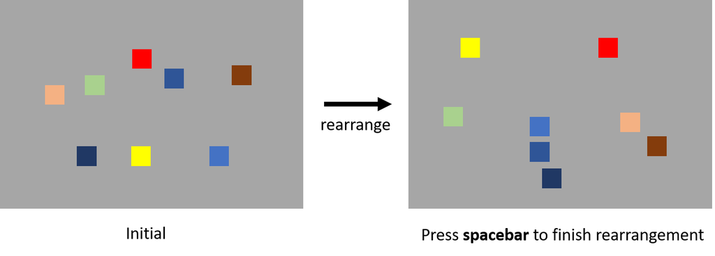

- The spatial distance between items represents the similarity between them.

## Multi-Items Rearrangement Task

- Advantages:
  - Faster than Paired-Comparison task.
  - Finer scale comparing to rating.
  - Less effect from diagnosticity effect.
- Disadvantages:
  - Potential distortion from high dimensional feature space.

## Experiment 1

Testing potential distortion.

- Materials:

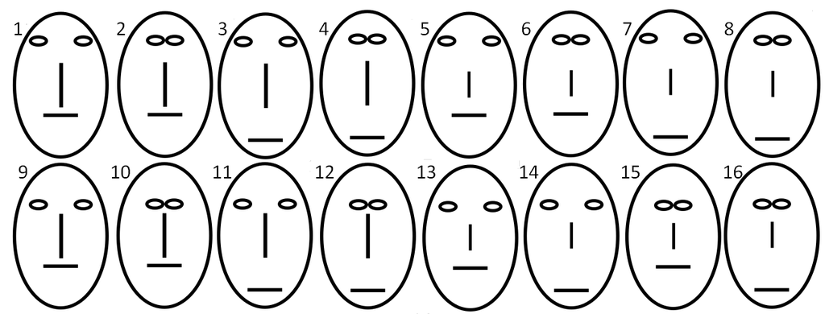

- 10 participants, two sessions
- MIRT -> Paired-Comparison task.
- MIRT contains 8 items in a trial.

## Experiment 1

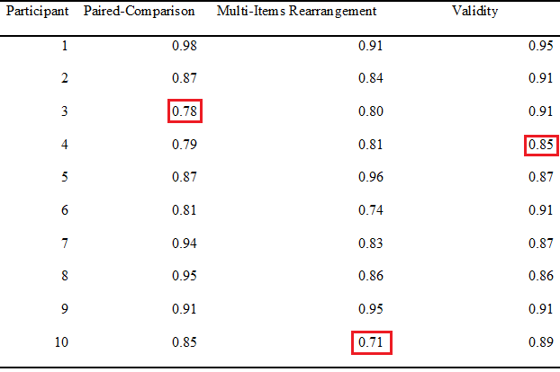

## Experiment 1

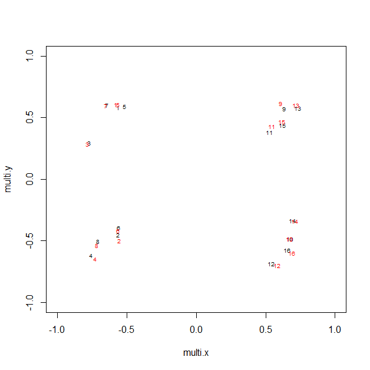

Paired-Comparison: red; MIRT: black

## Experiment 1

- Time to complete:
  - MIRT: 475.6s
  - Paired-Comparison task: 905.1s
  - BF = 313.75
- MIRT is faster.
- The reliability and validity are good.
- There are generally no distortion problem in MIRT with the materials.

## Experiment 2

Testing continuous material

- Everything is the same as Experiment 1.
- Materials:

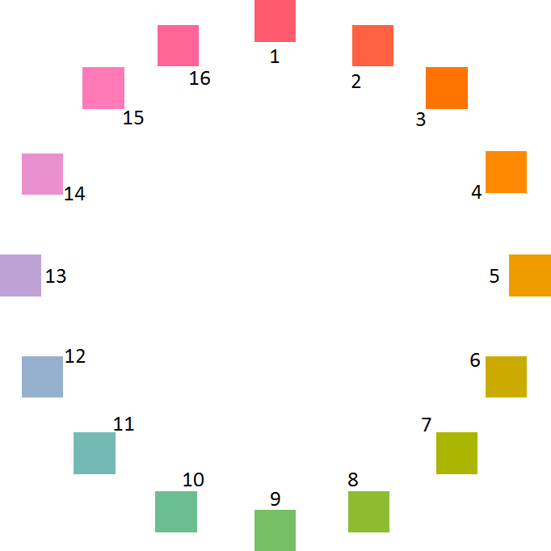

## Experiment 2

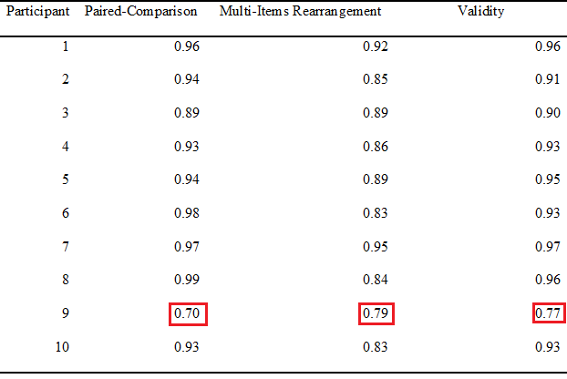

## Experiment 2

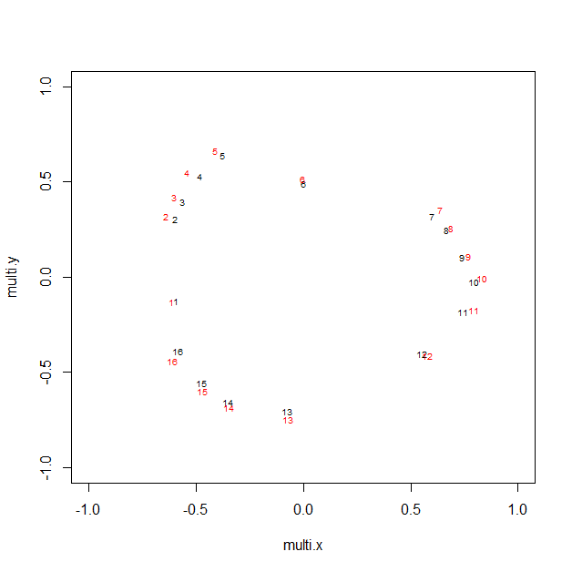

Paired-Comparison: red; MIRT: black

## Experiment 2

- Time to complete:
  - MIRT: 338.3s
  - Paired-Comparison task: 713.9s
  - BF = 15.7
- Both tasks can measure the similarity matrix of the items from continuous materials.
- Be aware of the gaps in the colorwheel.

## Conclusion

- MIRT is faster then Paired-Comparison task.
  - MIRT can be even faster if presenting more items at once.

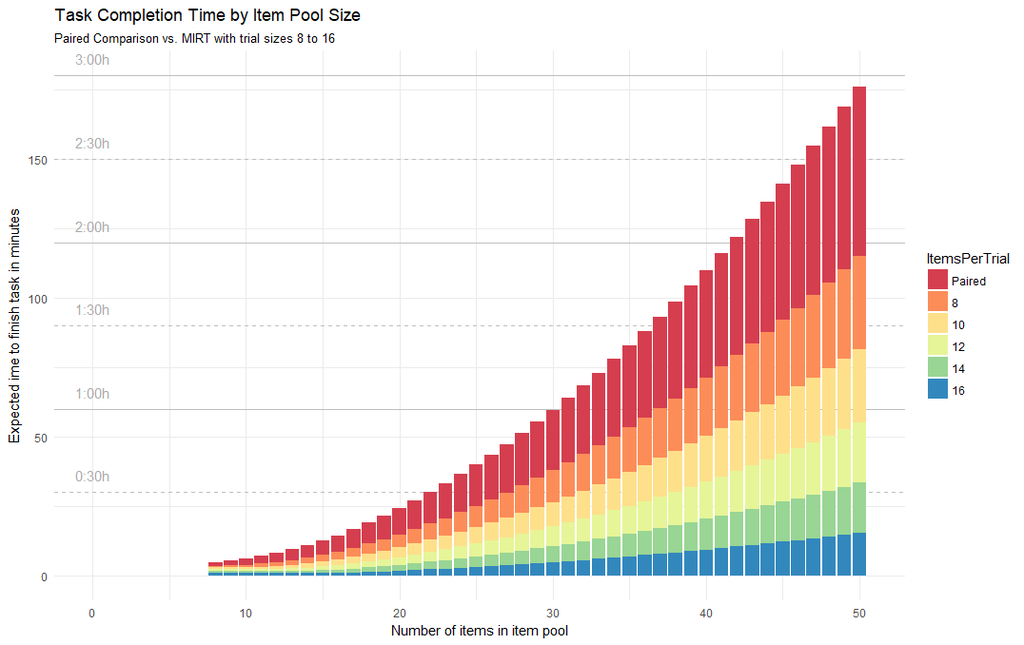

- MIRT acquired similar similarity matrix as Paired-Comparison task.
- MIRT is as reliable as Paired-Comparison task.

## That's it!

Thanks for the attention. Please ask mean questions.